# Uygulama Notları: 5

## FİZ219 - Bilgisayar Programlama I | 06/11/2020

**Döngü ve Karar Cümleleri (I)**

- Giriş
- Dosya, dosya, dosya...
  - İleri seviye müdahale
- İlk ciddi programımız: Kök Bulucu
- For... döngüsü
  - Her iterasyonun sonuçlarını biriktirmek
- if kontrol/karar mekanizması
  - break komutu
- Çoklu for döngüleri
- Ödev
  - Asal sayı bulucu
  - Kök söktürücü

Emre S. Tasci emre.tasci@hacettepe.edu.tr

# Giriş

Şimdiye kadar basit tanımlar ile, skalerler, vektörler ve matrisleri içeren işlemleri nasıl yapacağımızı inceledik. Fakat bütün bunlar program yazmaktan çok, gelişmiş bir hesap makinesi kullanmaya benziyor. Bilgisayarları daha çok, milyonlarca, milyarlarca tekrarlı işleri bıkıp usanmadan yaptırmak için kullanırız. Einstein'e atfedilen (ama büyük ihtimalle başkasına (Leo Cherne) ait olan) bir sözü alıntılarsak:

> Bilgisayarlar inanılmaz hızlı, doğru ve aptallar. İnsanlar ise inanılmaz yavaş, kusurlu ve zekiler. İkisinin birlikteliği her şeyin ötesinde bir güç olur.

*(The computer is incredibly fast, accurate, and stupid. Man is incredibly slow, inaccurate, and brilliant. The marriage of the two is a force beyond calculation)*

# Dosya, dosya, dosya...

Artık hepimiz büyüdük, komutları tek tek yorumlayıcıya girmek yerine, bir dosyaya yazacağız. Bu şekilde, hem geriye dönük düzeltmeleri rahatça yapabileceğiz, hem de ihtiyacımız olduğunda, bulundukları klasörden çağırıp kullanabileceğiz

GNU Octave dosyaları, ".m" uzantılıdır (bunun sebebinin eşleniği olan MATLAB'la uyumluluk olduğunu düşünüyorum -- bu vesileyle, Octave dosyalarınızı MATLAB'da, MATLAB dosyalarınızı da Octave'da sorunsuzca çalıştırabilirsiniz -- sadece çok çok ileri seviyelerde farklılıklar ortaya çıkmakta).

Octave'ı eğer GUI olarak kullanıyorsanız, işler bir nebze kolay:

Açıklamalara başlamadan önce -- eğer sizde menüler/pencereler karmakarışık/istemediğiniz bir halde ise, her zaman için "Window" menüsünün en altında yer alan "Reset Default Window Layout" seçeneği ile varsayılan görünüm düzenine dönebilirsiniz, sıkıntı yok, panik yok ;)

[figure not shown]

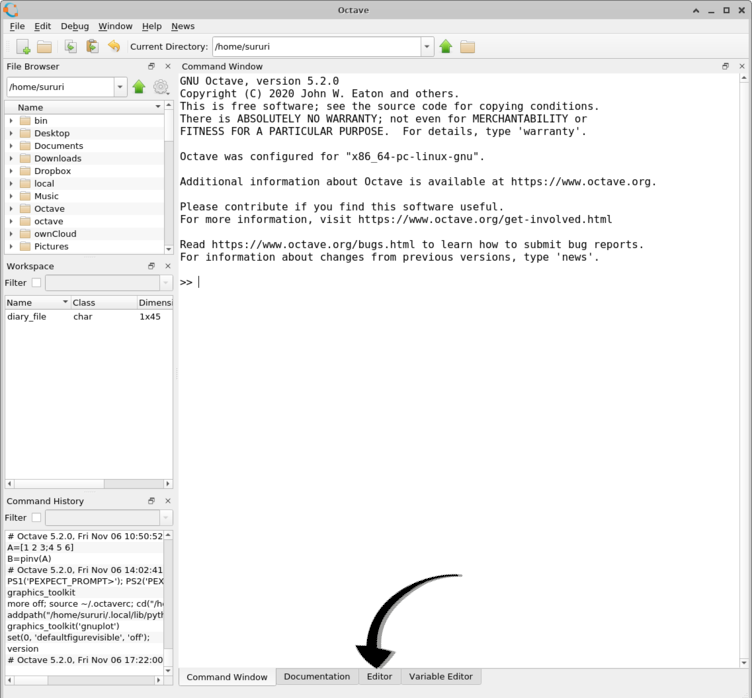

Alttaki kulakçıklardan "Editor"ü seçin. Tebrikler, artık buradan dosyalara programlarınızı yazabilirsiniz! 8) Yalnız, "buradan yaz, 'Command Window'dan çalıştır" yaklaşımı kısa sürede yorucu olacağından, size tavsiyem, yazım ve çalıştırma pencerelerini yan yana ayarlamanız. Bunun için aşağıdaki ekran görüntüsündeki okun göstermekte olduğu "Editor" kulakçığına basılı tutup, mouse'un tuşunu bırakmadan hareket ettirin.

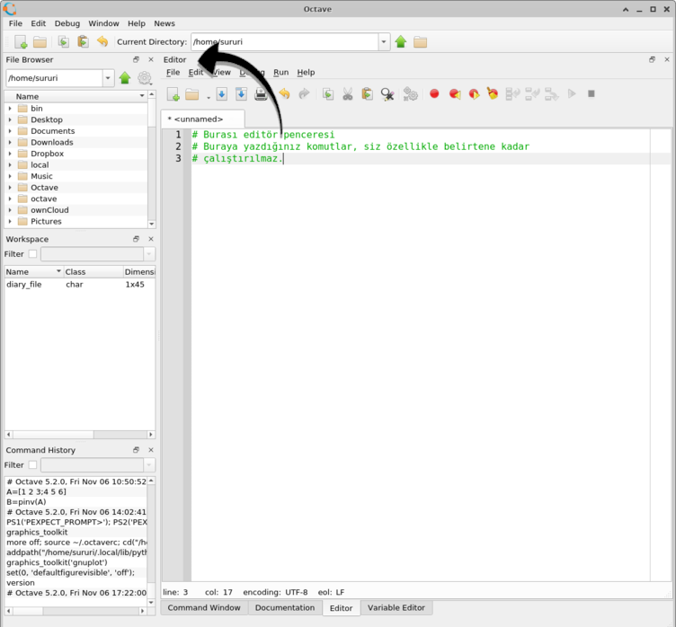

Biraz hareket ettirince, farklı bölgelerin, farklı doğrultularda gölgelendiğini görürsünüz -- bu, mouse'un tuşunu bırakmanız halinde, editor penceresinin o şekilde yerleştirileceğini size haber verir. Gönlünüze göre bir konum & yönelim bulup, mouse'un tuşunu bırakın:

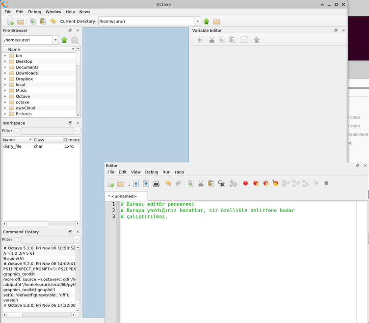

Yan tarafına da "Command Window"u aktive ederseniz, bu iş tamamdır:

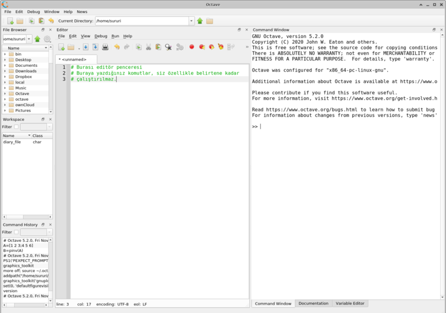

Editördeki kodunuzu birden fazla şekilde çalıştırabilirsiniz:

- "Run" menüsünden "Save File and Run" seçerek,
- Çarklar şeklindeki ikona klikleyerek,
- "Command Window" penceresine betik dosyasının adını uzantısız olarak yazarak.

Eğer GUI değil de, CLI kullanıyorsanız, o zaman sisteminize ve keyfinize bağlı olarak güzel bir editör kullanmanızı tavsiye ederim. Önemli olan, programlarınızı "yalın metin" (*plain text*) biçiminde ve ".m" uzantısıyla kaydedebilmeniz (Windows kullanıcıları çok dikkatli olsunlar, dosyayı kaydederken tür olarak "Metin Belgesi" seçili olursa, dibine otomatikman ".txt" uzantısı ekler; bu nedenle, "Tüm Dosyalar" türünü seçip, öyle ".m" uzantılı olarak kaydedin. İlgili dersimizin videosunda, arkadaşlarınız sağolsun, onların bilgisayarları üzerinde gerek Windows, gerekse MacOs işletim sisteminde gösterimler var (Linuxçulara zaten tarif gerekmez! ;).

Programlarımızı yazdığımız hale "betik" (*script*) diyoruz. Arada çok önemli bir fark yok, yani program ile betiği birbirinin yerine kullanırsanız dünyanın sonu gelmez ama bir sinema filmi programsa, senaryosuna betik diyebiliriz. Yani 'program', betiğin çalıştırıldığında ortaya çıkardığı oluşum oluyor aslında...

Bir betiği, dosyasının ismini uzantısız olarak yazarak çalıştırırız. Octave dosyayı kendi çalıştırıldığı aktif yerde ve ön tanımlı birkaç yerde daha arar.

Aktif yeri görmek için `pwd` komutunu girin:

```
octave:1> pwd
ans = /home/sururi
```

İlk betiğimizi yazıp `ilk_prog.m` adıyla `pwd` komutuyla gördüğümüz yere kaydedelim. Eğer oraya kaydetmenize izin verilmiyorsa, masaüstüne kaydedin, sonra Octave içinden `cd` komutuyla masaüstünüzün olduğu yere gidin, örneğin:

```
octave:2> cd "/home/sururi/Desktop/"
octave:3> pwd
ans = /home/sururi/Desktop
```

Windows'da dosya yerleri "ters slash" ("\") işareti ile gösterilmesine karşın `cd` ile yine düz slash'ler ("/") kullanarak belirtin -- en azından dersimizde o şekilde başardık 8) örneğin:  
`cd "C:/Users/Emre Sururi/Desktop"`

Bu aşamadan itibaren artık kodlarınızı bir dosyaya yazıp, o dosyadan çağırabildiğiniz varsayılacaktır. Eğer sıkıntı yaşarsanız, ilgili dersimizin videosundan dikkatlice izleyin, sıkıntı hala devam ederse de tabii ki benimle iletişime geçin, halletmeye çalışalım. 8)

## İleri seviye müdahale

Diyelim ki, bilgisayarınızda, tercih ettiğiniz bir yere `Octave_Betiklerim` gibi bir klasör oluşturdunuz ve buraya koyduğunuz betiklerin Octave tarafından o sırada nerede aktif olursa olsun bulunmasını istiyorsunuz. Bu durumda klasörümüzün bilgisini Octave'a `addpath()` komutu ile ekleriz (örn., *addpath("C:/Klasorumuzun/oldugu/yer/Octave_Betiklerim")*). Bu komutu çalıştırdıktan sonra, Octave artık oradaki betikleri de bilecektir (Octave'ın siz bir şey yazdığınızda o isimdeki betikleri aradığı yerler listesini `path` komutunu girerek görebilirsiniz). Octave'ı her açtığınızda tekrar tekrar bu -veya başka- komutları yazmak istemiyorsanız, kişisel klasörünüze `.octaverc` adında bir dosya oluşturup, Octave'ın her açıldığında çalıştırılmasını istediğiniz komutları bu dosyaya girersiniz.

# İlk ciddi programımız: Kök Bulucu

Artık dosyalara kod yazmayı öğrendiğimize göre, ilk ciddi programımızı yazabiliriz: $a x^2+b x+c=0$ formundaki ikinci dereceden denklemin köklerini bulan "kök bulucu" programı!

İkinci dereceden denklemlerin köklerini nasıl bulacağımızı yaklaşık olarak 2000 yıldan beridir biliyoruz:

$$x_{1,2}=\frac{-b\pm \sqrt{b^2 - 4ac}}{2a}$$

O zaman programımızla, sözgelimi: $3x^2-7x+4=0$ denkleminin köklerini bulalım (genel denklemle karşılaştırdığımızda burada $a=3$, $b=-7$, $c=4$ olduğunu görebiliyoruz... değil mi? 8)

```matlab
# a*x^2 + b*x + c = 0

a = 3
b = -7
c = 4

delta = b^2 - 4*a*c

x1 = (-b - sqrt(delta)) / (2*a)
x2 = (-b + sqrt(delta)) / (2*a)
```

```
a =  3
b = -7
c =  4
delta =  1
x1 =  1
x2 =  1.3333
```

Hazır kökleri bulmuşken, grafiğini de çizdirip, ilgili aralıklarda kontrol edelim, bakalım hakikaten o $x$ değerlerinde x-eksenini kesiyor mu...

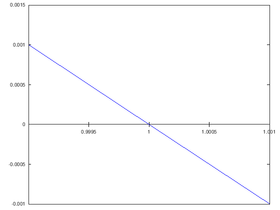

```matlab
x = linspace(x1-1E-3,x1+1E-3,100);
y = a*x.**2+b*x+c;

plot(x,y,"b-")
set(gca, "xaxislocation", "origin")
xticks(x1-1E-3:5E-4:x1+1E-3)
```

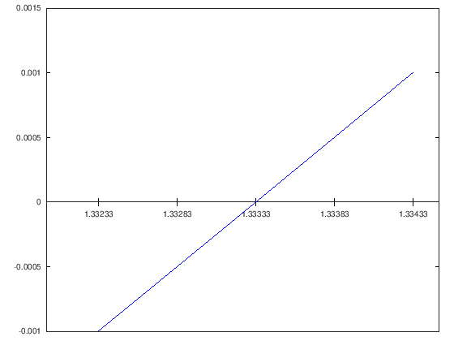

```matlab
x = linspace(x2-1E-3,x2+1E-3,100);
y = a*x.**2+b*x+c;

plot(x,y,"b-")
set(gca, "xaxislocation", "origin")
xticks(x2-1E-3:5E-4:x2+1E-3)
```

Bunları yapan programımızın "kok_bulucu.m" dosyasının içeriği şu şekilde olacak:

```
# Kök bulucu program.
# Tanımlanan a, b ve c değerleri için
# a*x^2 + b*x + c = 0
# denkleminin kökünü bulur.

# a,b,c değerleri tanımlanıyor
a = 3
b = -7
c = 4

delta = b^2 - 4*a*c

# Hazır formülden kökler hesaplanıyor
x1 = (-b - sqrt(delta)) / (2*a)
x2 = (-b + sqrt(delta)) / (2*a)

# x1 değeri için zoom'lanmış bölge çiziliyor
x = linspace(x1-1E-3,x1+1E-3,100);
y = a*x.**2+b*x+c;

plot(x,y,"b-")
set(gca, "xaxislocation", "origin")
xticks(x1-1E-3:5E-4:x1+1E-3)

# x2 grafiğine geçmeden önce
# bir tuşa basılana kadar bekletiyoruz.
pause


# x2 değeri için zoom'lanmış bölge çiziliyor
x = linspace(x2-1E-3,x2+1E-3,100);
y = a*x.**2+b*x+c;

plot(x,y,"b-")
set(gca, "xaxislocation", "origin")
xticks(x2-1E-3:5E-4:x2+1E-3)
```

Ek bilgi: Octave'da n. dereceden polinomların kökünü halihazırda -hem de çok daha etkin bir biçimde- hesaplayan `roots` fonksiyonu zaten var ama zaten asıl amacımız kökleri bulmak değil de, programlamayı öğrenmek olduğundan oturup açık açık kendimiz yazdık. 8)

```matlab
roots([3,-7,4])
```

```
ans =

   1.33333
   1.00000
```

# For... döngüsü

İlk örnek olarak, 5 kere "Merhaba!" dedirtelim. Bir şeyi en basit şekliyle, yani biçimsiz, süssüz yazdırmak için `disp()` komutunu kullanırız(*):

```matlab
disp("Merhaba!")
disp("Merhaba!")
disp("Merhaba!")
disp("Merhaba!")
disp("Merhaba!")
```

```
Merhaba!
Merhaba!
Merhaba!
Merhaba!
Merhaba!
```

Bu örnekteki gibi aynı işlemi birden fazla kez yaptırmak istiyorsak, bir `for` döngüsünün içine alırız:

```matlab
for i = 1:5
   disp("Merhaba!")
endfor
```

```
Merhaba!
Merhaba!
Merhaba!
Merhaba!
Merhaba!
```

Döngüyü tanımlamak için, `for` diye başlayıp, bir değişkenin alacağı değerleri atarız. Burada i'nin 1'den 5'e olan sayıları, yani [1,2,3,4,5] değerlerini alacağını bildiriyoruz. ("for" denmesinin sebebi: "i'nin 1'den 5'e kadar olan değerleri için şunları yap:" mantığı). Döngünün, yani *for bloğunun*, sınırlarını da `endfor` diyerek bildiriyoruz. Octave'da satırların başlarına eklenen boşluklar kaale alınmaz ama blokların nerede başlayıp bittiğini bir bakışta kolayca görmek için bu şekilde girintiler kullanmak epey faydalı bir alışkanlıktır (hatta o kadar faydalıdır ki, Python dilinde mecburi kılınmıştır 8).

5 kere "Merhaba!" demek, tabii ki ne kadar iyi kalpli bir insan olduğumuzu gösterse de, daha faydalı işlere doğru yol açalım. Örneğin, yine 5 kere "Merhaba!" diyelim ama bunu yaparken, merhabalarımızı da sayalım:

```matlab
for i = 1:5
   disp(i)
   disp("Merhaba!")
endfor
```

```
 1
Merhaba!
 2
Merhaba!
 3
Merhaba!
 4
Merhaba!
 5
Merhaba!
```

Döngü içinde değişken olarak `i`'yi kullandığımızı ve i'nin değerinin her çevrimde değiştiğine dikkat edin. Sadece i'yi yazdıralım:

```matlab
for i = 1:5
   disp(i)
endfor
```

```
 1
 2
 3
 4
 5
```

Biliyoruz ki `1:5` aralık operatörünü kullanarak, 1'den başlayıp, birer birer arttırarak 5'e kadar sayıyor, yani aslında `1:5` de yazsak, `[1 2 3 4 5]` de yazsak tamamıyla aynı şeyler:

```matlab
for i = [1 2 3 4 5]
   disp(i)
endfor
```

```
 1
 2
 3
 4
 5
```

E madem ki sayı dizisinin değerleri üzerinden gidiyor, karışık sayılar verelim, bakalım o zaman ne olacak:

```matlab
for i = [5 -2 1 2 -7 -5 9]
   disp(i)
endfor
```

```
 5
-2
 1
 2
-7
-5
 9
```

Beklediğimiz üzere, `i`, tanımlandığı değerler üzerinden, sırayla, sona ulaşana kadar ilerliyor. Değerler önceden de tanımlanmış olabilir:

```matlab
degerler = [-3, 2, -7, -8, 5, 2];
for i = degerler
   disp(i)
endfor
```

```
-3
 2
-7
-8
 5
 2
```

Biraz da işe yarar şeyler yapalım, örneğin, 7'den 10'a kadar olan sayıları toplayalım:

```matlab
toplam = 0;
toplam = toplam + 7;  # Toplama 7 ekledik,   0 + 7 =  7 oldu.
toplam = toplam + 8;  # Toplama 8 ekledik,   7 + 8 = 15 oldu.
toplam = toplam + 9;  # Toplama 9 ekledik,  15 + 9 = 24 oldu.
toplam = toplam + 10; # Toplama 10 ekledik, 24 +10 = 34 oldu.
toplam
```

```
toplam =  34
```

Yukarıdaki kodu incelediğimizde, 4 satırın sadece tek bir faktörün değiştirilerek yazıldığını görüyoruz. Demek ki, for döngümüz orayı temsil edecek:

```matlab
toplam = 0;
for i = 7:10
   toplam = toplam + i;
endfor
toplam
```

```
toplam =  34
```

**(*) Dipnot:** *`disp()` komutunu kullanmasak da, `a` deyip enter'a basınca `a`'nın değerini, `"Merhaba Dünya!"` deyip enter'a basınca da "Merhaba Dünya!" yazdırabiliyoruz -- o halde ne demeye fazladan komut koymuşlar?* diye düşünebilirsiniz, en doğal hakkınızdır. disp() kullanımının ikisi kodsal, biri ise yorum açısından faydalı üç kullanımı vardır. Kodsal olarak: bir satırda 3 değişken tanımladığınızı, bunları yaparken de ekrana yazdırmak istediğinizi varsayalım. Birden fazla komut cümlesini ";" işareti ile aynı satıra yazabiliyoruz, örneğin:

```matlab
a = 1; b = 2; c = 3
```

```
c =  3
```

ama noktalı virgül aynı zamanda çıktı baskıladığından, a ile b'nin atanmış değerlerini de görmek için disp() kullanabiliriz:

```matlab
a = 1; disp(a); b = 2; disp(b); c = 3; disp(c)
```

```
 1
 2
 3
```

doğrudan değerlerin yazıldığına dikkat edin (aslında aynı satırda farklı komutları "," kullanarak yazınca, sanki enter'a basmış gibi oluyoruz). Bu da bizi ikinci kodsal faydaya getiriyor: `disp` ile normalde ekrana yazılan bilgiyi bir değişkene de atayabiliriz (`a = 5; b = disp(a);` gibi).

Ama disp'in asıl faydası, açık şekilde ekrana bir şeyler yazdırdığımızı fark ettirmek (bunu özellikle *debugging* dediğimiz, programlardan hataları ayıklama işlemlerinde kontrol için sık sık kullanırız), ki bu da yorumsal faydası olmakta.

Zaten asıl kaliteli, biçimlendirilmiş türden ekrana/dosyaya yazdırmak için `printf()`'i öğrenip rahat edeceğiz -- `disp()` bu açıdan epey kabaca, iki değişkeni yan yana bile yazdıramıyoruz neticede...

## Her iterasyonun sonuçlarını biriktirmek

Fibonacci sayıları, genellikle (0,1) ile başlayan, n. terimin kendisinden önce gelen iki terimin toplamı olarak hesaplandığı ve doğada da şüphe uyandıracak bir sıklıkla karşımıza çıkıp duran bir seridir. Bir program yazıp, 0, 1, 1, 2, 3, 5, 8, ... diye giden bu seriyi hesaplayalım.

Yazmadan önce biraz düşünsek mi ne... ilk başta a = 0, b = 1 diye başladık... c = a + b deyince, c = 0 + 1 = 1 oldu, sonra d = b + c desek, d = 1 + 1 = 2 olur ama bunu bilgisayara tek tek yazmak bitirir bizi... Kafamızı kullanmak lazım...

Her seferinde bulduğumuz terime biz c,d,e,... diye isim verebiliriz ama bunu bilgisayara anlatmak biraz sıkıntılı olduğundan, süreci sistematikleştirmek lazım. Bunu da *kullan & at* mantığıyla yapalım:

1. a = 0, b = 1 olarak tanımla.
2. c = a + b olarak hesapla.
3. a'ya b'nin; b'ye c'nin değerini ata.
4. 1. adıma git.

Bu şekilde c'yi her hesaplayışımızdan sonra, a'ya b'nin, b'ye de c'nin değerlerini atadığımızdan, işlemi bir yana kaydırmış oluyoruz ve bu şekilde her zaman için "c = a + b" diyerek, yeni c değerlerini hesaplayabiliyoruz. Bunu koda dönüştürelim:

```matlab
clear;

a = 0
b = 1

for i = 1:10
   c = a + b
   a = b;
   b = c;
endfor
```

```
a = 0
b =  1
c =  1
c =  2
c =  3
c =  5
c =  8
c =  13
c =  21
c =  34
c =  55
c =  89
```

Burada ilk defa kullandığımız `clear` komutu, o ana kadar tanımladığımız bütün değişkenleri silip, Octave'ı sanki yeni açmışız gibi yapar.

Gayet güzel sonuç verdi. Peki, ekrana yazdırmak yerine, hesaplanan değerleri bir dizide nasıl saklarız? Bunun için biraz daha düşünelim:

```matlab
# Boş bir dizi tanımlayalım
dizi = []
```

```
dizi = [](0x0)
```

```matlab
# Bu diziye "1" elemanını ekleyelim:
dizi = [1]
```

```
dizi =  1
```

```matlab
# bir de 3 eklersek, dizimiz [1 3] olacak:
dizi = [1 3]
```

```
dizi =

   1   3
```

```matlab
# şimdi de -2 ekleyelim:
dizi = [1 3 -2]
```

```
dizi =

   1   3  -2
```

Bu şekilde dizimizi her seferinde yeniden tanımlıyoruz: önce o sıradaki mevcut değerlerini yazıyoruz, sonuna da yeni değerleri. Bu şekilde bakıldığında, pek "ekleme" olmuyor, düpedüz her seferinde diziyi baştan tanımlıyoruz. Ama bir şeye dikkat edin, dizinin değeri örneğin [1 3] iken, buna -2'yi eklemek için [1 3 -2] yazarken, aslında baştaki sayılar dizinin o andaki (yani ekleme yapılmadan önceki) halinin ta kendisi! E o halde, doğrudan o bilgiyi kullanabiliriz:

```matlab
dizi = [1 3]
```

```
dizi =

   1   3
```

```matlab
dizi = [dizi, -2]
```

```
dizi =

   1   3  -2
```

Bu kavramın bir benzeri kendine etki ettirilen işlemlerde görülür. Örneğin a = 5 olsun, sonra a'ya 2 ekleyelim:

```matlab
a = 5
```

```
a =  5
```

```matlab
a = a + 2
```

```
a =  7
```

Bu komutu bir daha tekrarladığımızda, a bu sefer 7 + 2 = 9 olacaktır:

```matlab
a = a + 2
```

```
a =  9
```

Bu davranış, dizimiz için de benzer şekilde geçerli:

```matlab
dizi
```

```
dizi =

   1   3  -2
```

```matlab
dizi = [dizi 19]
```

```
dizi =

    1    3   -2   19
```

```matlab
dizi = [dizi 19]
```

```
dizi =

    1    3   -2   19   19
```

Tekrardan Fibonacci dizisi örneğimize dönelim. Sonuçları `sonuclar` isimli bir dizide toplamak için, öncelikle bu isimde bir dizi tanımlayalım, ilk iki eleman olarak da a ile b elemanlarını belirleyip, sonrasında c'nin değerini her hesapladığımızda, bu diziye ekleyelim:

```matlab
clear;

a = 0
b = 1

sonuclar = [a, b];

for i = 1:10
   c = a + b;
   sonuclar = [sonuclar, c];
   a = b;
   b = c;
endfor

sonuclar
```

```
a = 0
b =  1
sonuclar =

    0    1    1    2    3    5    8   13   21   34   55   89
```

Çoğu zaman elde ettiğimiz hesap sonuçlarını doğrudan ekrana yazdırmak yerine, sonrasında işleyebilmek adına, bu şekilde dizilerde saklarız.

# if kontrol/karar mekanizması

Bilgisayarlara "bu böyle mi? Eğer öyleyse, şöyle yap" dememizin yolu `if` komutu ile olur. `if` ile her zaman için cevabı ya "doğru" ("öyledir") ya da "yanlış" ("öyle değildir") olarak verilecek bir önerme sunarız. Yani "5, 3'ten büyük müdür?" ya da "a dizisinin eleman sayısı 6 mı?", "hayatın anlamı 42 mi?" gibi önermeler geçerlidir fakat "hangi sayılar üçten büyük?", "hayatın anlamı nedir/kaçtır?" veya "zzzt ne demek kompodor?" gibi sorular önerme olmadığından geçerli değildir. Geçerli sorularımızı önerme şeklinde vermemiz gerekiyor yani "5, 3'ten büyüktür", "a dizisinin eleman sayısı 6'dır" veya "hayatın anlamı 42'dir" şeklinde.

Eğer belirttiğimiz önerme doğru ise `if` ile `endif` arasında tanımlanan kod bloğu çalıştırılır; önerme doğru değilse, ilgili bloktaki kod atlanır, çalıştırılmaz.

```matlab
a = 5;

if(a > 5)
  disp("a, 5'ten büyük.")
endif

if(a == 5)
  disp("a, 5'e eşit.")
endif

if(a < 5)
  disp("a, 5'ten küçük.")
endif
```

```
a, 5'e eşit.
```

Yukarıdaki programımızda 3 adet kontrol işlemi var: a'ya 5 değerini atayıp, kontrollere geçiyoruz. İlkine gelindiğinde önermemiz *"a, 5'ten büyüktür"* ama a değerimiz 5 olduğundan ve bir sayı kendinden büyük olamayacağından, bu önerme yanlış oluyor ve ilgili bloğun içindeki `"a, 5'ten büyüktür" yazdır` ifadesi çalıştırılmıyor. Bir sonraki kontrole geldiğimizde bu seferki önermemiz *"a, 5'e eşittir"* ve hakikaten de öyle olduğundan, bu önerme doğru ve bu nedenle ilgili blok çalıştırılıyor ve "a, 5'e eşit." cümlesi ekrana yazdırılıyor. Buradaki "eşittir" ifadesinin `==` sembolü ile verildiğine dikkat edin. Şimdiye kadar değer atama yaparken kullandığımız `=` sembolü "a = 5" gibi bir cümlede kullandığımızda "a'ya 5 değerini ata" anlamına geliyor; halbuki "a == 5" dediğimizde, bu "a, 5'e eşit (mi?)" anlamına gelmekte. Üçüncü önerme de, yani a'nın 5'ten küçük olduğu da doğru olmadığından, onunla ilgili blok da çalıştırılmıyor. (Gelecek ders, bu türden alakalı kontrol ifadelerini tek bir ifadede nasıl toplayabileceğimizi de göreceğiz.)

`if` bu şekilde tek başına kullanıldığında pek işlevsel görünmese de, `for` döngüsünün içine yerleştirildiğinde çok etkili bir hale gelir. Bir sonraki örneğimizde verilen aralıkta 6'ya tam bölünebilen sayıları bulduralım. Bir sayının 6'ya bölünüp bölünmediğini kontrol için, modüler aritmetik kullanacağız, yani sayının 6'lık moddaki karşılığının 0 olup olmadığına bakacağız:

```matlab
mod(5,6) # 5'in 6'lık moddaki değeri
```

```
ans =  5
```

```matlab
mod(11,6) # 11'in 6'lık moddaki değeri
```

```
ans =  5
```

```matlab
mod(18,6) # 18'in 6'lık moddaki değeri
```

```
ans = 0
```

`mod` fonksiyonunun nasıl çalıştığını gördüğümüze göre, işe koşalım:

```matlab
clear;

a = 11; # Başlangıç
b = 30; # Bitiş

sonuclar = [];

for n = a:b
    if (mod(n,6) == 0)
       sonuclar = [sonuclar, n];
    endif
endfor

sonuclar
```

```
sonuclar =

   12   18   24   30
```

Örneğimizi bir adım daha ileri götürelim, biz başlangıcı belirtelim, 10 tane bulunca dursun. Bu kontrolü nasıl yaparız? `sonuclar` dizisinin eleman sayısını kontrol ederek tabii ki! 8)

Nerede biteceğini bilemediğimizden (ille 6'ya bölünen sayılar gibi düşünmeyin, asal sayılar da olabilir, 3'e bölünenler de, karesinin üç fazlası kökünün 5 eksiğinden büyük sayılar da... önemli olan düşünce ve uygulama tarzı), yeterince büyük, sözgelimi $10^15$'e kadar bir aralık kullanalım.

Bir dizinin kaç elemanı olduğunu "number of elements" teriminin kısaltması olan `numel` fonksiyonu ile de, bulabiliriz, `size` ve duruma göre `rows` veya `columns` komutları ile de, ama en pratiği `numel`i kullanmak.

```matlab
clear;

a = 11; # Başlangıç

sonuclar = [];

for n = a:1E15
    if (mod(n,6) == 0)
       sonuclar = [sonuclar, n];
    endif
    if (numel(sonuclar)==10)
       break
    endif
endfor

sonuclar
```

```
sonuclar =

   12   18   24   30   36   42   48   54   60   66
```

## break komutu

Yukarıdaki örnekte yeni bir komut kullandık: `break`. Bu komut, o anda içinde bulunulan döngüyü sonlandırır. Eğer break kullanmasaydık, döngü neredeyse sonsuza kadar sürerdi... bu şekilde gerektiği yerde döngüyü *kırıyoruz*.

[figure not shown]

Yukarıdaki örnek, dikkat edecek olursanız, çok akıllıca yazılmış bir kod değil. İleride çoklukla tekrar edeceğim üzere `if` faydalı ama işlemci zamanı açısından pahalı bir komuttur: bilgisayarlar tekrarlı işler için süper uygun, karar verdirme açısından biraz masraflı arkadaşlardır. Peki biz yukarıdaki örnekte ne yapıyoruz?

Bir ara verip, başka bir durumdan bahsedelim: diyelim ki bir arkadaşınızla birlikte hediye paketleri hazırlıyorsunuz. Arkadaşınız hediyeyi alıp kutuya koyuyor, siz de kutuyu alıp, hediye paketi yapıyorsunuz, yapılan iş bu. Üç oda olsun: Arkadaşınız hediyeleri soldaki odada kutulara koyuyor, sonra ortadaki odadaki masanın üzerine bırakıp sizin kapıyı tıklatıp masaya paketlenmek üzere hediyeyi koyduğunu bildirip, bir sonraki hediyeyi kutuya koymak üzere yine kendi odasına çekiliyor. Siz de kendi odanızdan orta odaya geçerek hediyeyi alıyor, kendi odanıza getirip paketliyorsunuz. Arkadaşınız farklı farklı hediyelerle uğraştığından belli bir süre olmuyor, hepsinin zamanı farklı. Bu durumda, en mantıklı olan şey, arkadaşınız "hediyeyi masaya koydum, gelip paketleyebilirsin" anlamında kapınızı çaldığında kalkıp masaya gitmeniz. Bunu durup dururken yapmanız hem zaman kaybı hem de yorgunluk. Böyle anlatınca ne kadar mantıklı geliyor değil mi? Şimdi yukarıdaki kodun sıkıntılı kısmına bir daha göz atalım:

```
for n = a:1E15
    if (mod(n,6) == 0)
       sonuclar = [sonuclar, n];
    endif
    if (numel(sonuclar)==10)
       break
    endif
endfor
```

Burada, n 6'ya bölünse de (yani sonuclar dizisinin elemanı bir artsa da), bölünmese de (yani sonuclar dizisinin eleman sayısında bir değişiklik olmasa da), her halikarda gidip "sonuclar dizisinin eleman sayısı 10 oldu mu?" diye sorup duruyoruz ("geldik mi? geldik mi? peki şimdi geldik mi?") -- halbuki mantıklı olan, bu soruyu sadece sonuclar'a ekleme yaptığımız zaman, yani eleman sayısının bir arttığı zaman sormamız olurdu:

```matlab
clear;

a = 11; # Başlangıç

sonuclar = [];

for n = a:1E15
    if (mod(n,6) == 0)
       sonuclar = [sonuclar, n];
       if (numel(sonuclar)==10)
           break
       endif
    endif
endfor

sonuclar
```

```
sonuclar =

   12   18   24   30   36   42   48   54   60   66
```

# Çoklu for döngüleri

İki `if` bloğu iç içe olur da, iki `for` bloğu iç içe olmaz mı? İki boyutlu, $(3\times4)$'lük bir matrisin $(i,j).$ hücresinin değerini $i+j$ olarak tanımlamak için satır ve sütunlar üzerinden döngülerimizi iç içe kuralım:

```matlab
clear;

# Boş bir matrisle başlayalım
M = [];

for satir = 1:3
disp("* satır:")
   disp(satir)
   for sutun = 1:4
       disp("  ** sütun:")
       disp(sutun)
       M(satir,sutun) = satir + sutun;
    endfor
endfor

M
```

```
* satır:
 1
  ** sütun:
 1
  ** sütun:
 2
  ** sütun:
 3
  ** sütun:
 4
* satır:
 2
  ** sütun:
 1
  ** sütun:
 2
  ** sütun:
 3
  ** sütun:
 4
* satır:
 3
  ** sütun:
 1
  ** sütun:
 2
  ** sütun:
 3
  ** sütun:
 4
M =

   2   3   4   5
   3   4   5   6
   4   5   6   7
```

Sütun döngüsü bitince bu sefer ilk döngünün, yani satır döngüsüne gidiliyor ve satir'ın değeri 2 yapılıyor ve sütun döngüsü başlatılıyor (sutun, yine 1'den 4'e kadar işletiliyor).

Böyle böyle, adım adım, matrisin her bir satırı için sütunlar işlenmiş oluyor.

# Ödev

## Asal sayı bulucu

1 ile 300 arasındaki asal sayıları bulan program yazınız. (Derste de belirttiğim üzere: burada marifet hazır kod kullanmak değil, `for` ve `if` yeteneklerinizi sergilemek. Kodunuzun doğruluğunu `primes(300)` komutunun sonucuyla kıyaslayarak kontrol edebilirsiniz).

## Kök söktürücü

Dersin başında incelediğimiz ve hazır formülle köklerini bulduğumuz $3x^2-7x+4=0$ denklemini tekrardan ele alalım. Kök bulmak için kullanılan metotların biri, kökün, tanım itibarı ile, fonksiyonun 0 değerini aldığı $x$ değeri olduğu gerçeğidir. Eğer fonksiyon kök değerinde 0'a eşitse, bu, fonksiyonun kök değerinde x-eksenini ya yukarıdan aşağıya, ya da aşağıdan yukarıya kesmesi anlamına gelir ("çoğu zaman" ;). O halde belli bir $x_0$ değerinden başlayıp, ufak ufak ilerleyerek şu şekilde (ve istenen hassasiyette) kökü bulacak bir algoritma kurabiliriz:

1. x0 = 0, adim_boyu = 1E-4 olarak tanımla.
2. a = 3*x0^2-7*x0+4 olarak hesaplayıp tanımla.
3. x1 = x0 + adim_boyu olarak tanımla.
4. b = 3*x1^2-7*x1+4 olarak hesaplayıp tanımla.
5. (a): a ile b'nin işaretleri birbirinden farklı ise aralarında kök var demektir.  
   kok = (x0+x1)/2 olarak yazdırıp programı bitir.  
   (b): a ile b'nin işareti aynı ise, arasında kök olmadığını varsayıp,  
   x0'a x1'in, a'ya b'nin değerini atayıp, 3. adıma git.

Bu algoritmayı anlayıp, program haline getirin.

(Bu vesileyle, bu algoritma işimizi görse de aslında epey hantal bir algoritma; ileride çok daha etkin metotlar göreceğiz kök bulma için)

**Bonuslar**

1. Katsayıları verilen herhangi bir ikinci dereceden polinomun köklerini bulsun, bulamıyorsa da bir süre sonra farkına varıp, pes etsin (örneğin $3x^2-7x+4=0$ için aramaya 2'den başlasaydık, sonsuza kadar gidecektik).
2. Tek (/dejenere) kökü olan 2. dereceden polinomun kökünü bulabilsin (örn. $x^2-4x+4=0$ denkleminin).
3. Gerçek kökü olmayan polinomun kökünün olmadığını anlasın (/pes etsin) (örn. $x^2-4x+5=0$)

Bonusları çözerken de yukarıdaki algoritmayı geliştireceksiniz: `if(b^2-4*a*c == 0) => "tek kök var"`, `if(b^2-4*a*c < 0) => "gerçek kök yok"` gibisinden cinlikler yapmaya izin yok. ;)